# Characterization of the microbiota from two vineyards at ‘Valle del Huasco’ in the northern Chile and inference of its metabolic pathways

Benjamín Valderrama,

2020

**Resume**

The microbiota associated with wine production can affect the flavor and aroma of the end product, therefore, its study can provide important tools for improving the wine quality. In this work I used the V4 region of the marker gen 16S rRNA to characterize the microbiota associated with the production chain of two vineyards at ‘Valle del Huasco’. Then, I identify taxonomic signatures present in the vineyards with LefSe and used Piphillin to infere its metabolic pathways. Here I report taxonomic signatures with highly specific presence in the vineyards. Some of them had never been described before, while others, like Lactobaillales, are widely recognized by their metabolic products and its capability to modify wine’s organoleptic properties. Anyway, prior to made strong conclusions about the effects of the microbiota in the production of the Pajarete, the bioinformatic approximation here exposed has to be complemented with experimental work. As consequence, this report represents the first step to explore the commercial worth of a wine with appelation of origin, and, therefore, unique in the world.

**Introduction**

The usage of microorganisms in the production of human food has been well studied since long ago (Ozen & Dinleyici, 2015). Nowadays, with next generation sequencing technologies (NGS), we have much more refined knowledge of its effects on our foods and drinks. In the case of red wine, the microbiota associated with its production chain is essential for fermentation of the most, and has consequences for relevant properties of the end product, like its flavor and aroma (Sirén, Mak, Fischer, Hansen, & Gilbert, 2019). Those features depends on volatile molecules present on it, which in turn are products of the metabolic activity of the microbiota(Parker, Capone, Francis, & Herderich, 2018). This evidence set the interest to study the microorganisms community and comprehend its relationship with the productive process, either to manipulate and potentiate wine’s organoleptic properties or to enhance its regionalized origin; being both scenarios capable increase its market value (Sirén et al., 2019; Varela & Borneman, 2017). As consequence, because of a wider knowledge of the microbiota associated with the production chain, huge business opportunities can be opened

In particular, the ‘pajarete’ is a sweet red wine which is produced, commercialized and consumed in small quantities (Castro et al., 2016). This wine has appellation of origin at northern Chile since 1953; a very singular situation within alcoholic drinks, being only preceded by the chilean ‘Pisco’ (Lacoste et al., 2016). This acknowledgment given almost a century ago, and its consequent outstanding position among other drinks, strongly contrast with its almost unnoticed condition in researching fields. Indeed, there is only one paper about ‘pajarete’. Because that publication only discuss historical aspects of the ‘pajarete’ wine (Castro et al., 2016), all data presented herein must be considered as a first approximation to the microbiota associated with the production of a previously unexplored product through bioinformatic methods.

Next generation sequencing methods has been routinely used to explore the communities of microorganisms living in diverse environments and food products. One common strategy to identify this microorganisms is thorugh the sequenciation of the marker gen 16S rRNA. Nevertheless, this technique cannot allow researchers to straightforward identify the metabolic activities of the community. In order to do that, it has been suggested to integrate different ‘omic’ strategies (metagenomics, transcriptomics, metabolomics, etc), but because of its high costs, they usually are very restrictive (Knight et al., 2018). Although indirect, a more economical approximation is the inference of microbiota’s metabolic pathways from the marker gen using statistical tools, sucha as Piphilin (Iwai et al., 2016), which was used in this work.

The relevance of the microbiota associated with wine’s production and the almost null knowledge we have about the ‘pajarete’, set the interest of the producers and researchers to inquire the composition of those communities, the metabolic pathways they bear and its consequences on wine’s propierties that can modify its value in the market. To do that, and in consideration of the exploratory nature of the analysis presented here, NGS technologies were used on the V4 region of the 16S rRNA marker gene, with the following inference of metabolic pathways present in the microbiota of two different producers of ‘pajarete’ to get insights in this unexplored territory.

**Objectives**

The general objective of this work is the characterization of the microbiota associated with the ‘pajarete’ produced in two artisan vineyards located in ‘Valle del Huasco’ in the northern Chile

In particular, it is expected to get insights about the composition of this community through the analysis of metagenomic data produced with NGS methods. Then, to analyze taxonomic features in the production chains used by the two vineyards and, finally, to predict the metabolic pathways beared by both communities.

**Material and methods**

- **Biological samples :**

The samples herein used come from two artisan vineyards which produce ‘pajarete’ at ‘Valle del Huasco’. Because of their desire to keep its production process in confidence, from now are referred as JF y VG. The V4 region of the 16S rRNA marker gene was amplified and sequenciated with 515F and 806R primers with Illumina MiSeq technollogy. In both vineyards, samples were collected in four different stages in the respective production chain, being them: “Before grinding” (JF1 and VG1), “After pressing” (JF4 and VG3), “Before the fermentation stop” (JF5 y VG4) and “After the fermentation stop” (JF6 and VG5). Nevertheless, the sampling process was made two month before the author received the data, and therefore was not involved on it.

- **Workflow for metagenomic data analysis :**

Metagenomic data was filtered acording to its quality. Qualified reads were then assigned to a taxonomic classification using dada2 algorithm (Callahan et al., 2016) and Silva database version 138.1 (Quast et al., 2013; Yilmaz et al., 2014). Then, two filters were applied to reads; the first filter was “supervised” and aims to remove reads assigned as “uncharacterized” at the phylum level, as well as reads considered as mitochondria, chloroplast or eukaryotic life forms. The second filter was “unsepervised” and was applied to discard reads within any phylum that has just one sinlge read. Then all samples were normalized by sum of squares with the vegan R package. After that, alpha diversity was calculated and a t-test was conducted to identify differences between vineyards. Later, beta diversity was calculated and PERMANOVA was then applied. Finally, taxonomic composition of samples were inquire by analyze its relative abundances at phylum and family level.

- **Taxonomic features associated with each producers and metabolic pathways inference :**

LefSe algorithm (Segata et al., 2011), free available in Dr. Huttenhower website, was used to identify taxonomic features in both production processes. This algorithm applies Kruskal-Wallis test (alpha = 0,05) and the subsequent Wilcoxon test (alfa = 0,05). Taxonomic features were identified given a LDA threshold score of 2.0. After that, Piphillin (Iwai et al., 2016) was used with data stored at Kyoto Encyclopedia of Genes and Genomes (KEGG) (Kanehisa & Goto, 2000) to infer functional metabolic pathways within microbial communities of both ‘pajarete’ producers. Multiple t-Test with Benjamini, Krieger y Yekutieli False Discovery Rate (Q = 1%) were conducted in order to identify pathways strongly associated with each vineyard.

**Results**

- **Relative abundance of the bacterial community within JF and VG vineyards, by phylum:**

To know the composition of the microbiota associated with this two producers of ‘pajarete’, relative abundances of the phyla present in the communities were plotted. The results are shown in Figure 1. Each phylum has a color, and each bar represents a different sample, properly identified by its name on the X axis, and its percentage value on the Y axis.

*Firmicutes* are predominant in samples JF1 and VG1, which correspond to stages before the processing of the most. Although *Firmicutes* representation within the community is lower in other samples, those microbiotas are still constituted almost entirely by *Firmicutes* and *Proteobacteria*

Fig 1: Barplot of relative abundances of the bacterial community within JF and VG vineyards, by phylum:

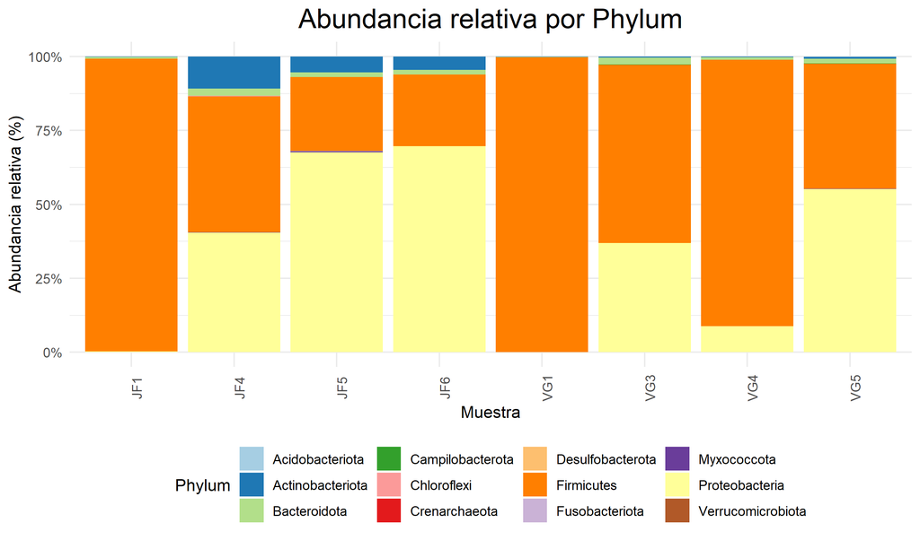

Alt text

- **Relative abundance of the bacterial community within JF and VG vineyards, by family:**

Additionally, the relative abundances of the microbiota associated with the two producers was inquire at family level of the taxonomy hierarchy. Results are shown in Figure 2. Each of the 12 most abundant families has a color. Also, reads that were not assign to any family (NA in the figure) were represented in dark gray. The contribution of all the other families is represented in light gray. Each bar represents a different sample, properly identified by its name on the X axis, and its percentage value on the Y axis.

Fig 2: Barplot of relative abundances of the bacterial community within JF and VG vineyards, by family:

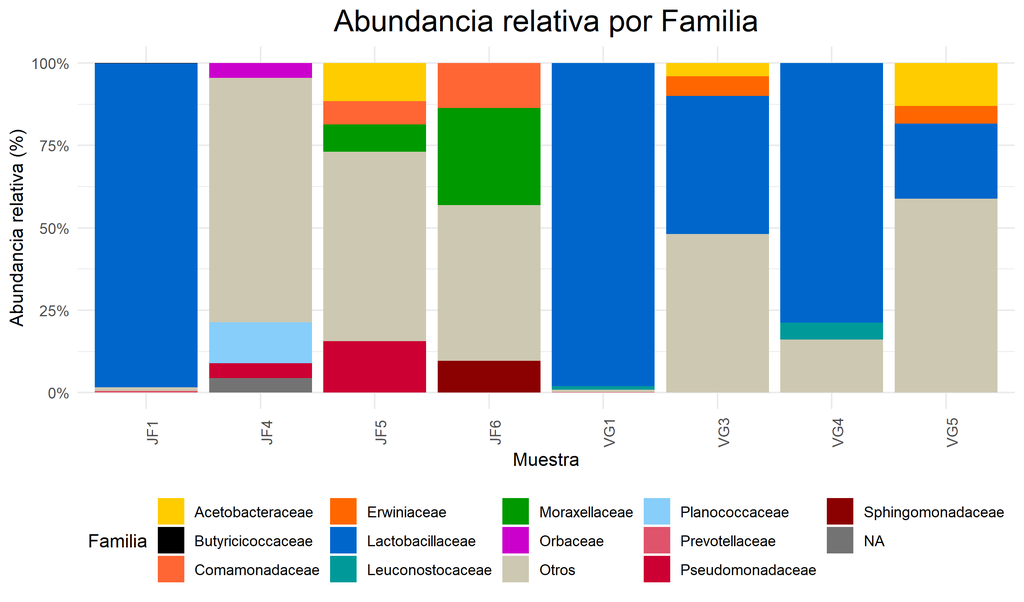

Alt text

- **Alpha diversity of the microbiota associated in JF and VG ‘pajarete’ producers**

Figure 3 shows alpha diversities of the two ‘pajarete’ producers. Three diferent metrics were used: Observed diversity, in A; chao1 index, in B and Shannon diversity in C. Two tiled t-Test were conducted to identify differences between producers: in A, (t6 = -2.46, P = 0,054); in B, (t6 = -2.46, P = 0,054) and in C, (t6 = 0.62, P = 0.56). As consequence, the observed differences are not statistically significant for any metric. Samples showed in Red comes from JF producer, and those in Green comes from VG.

Fig 3: Alpha diversity of the communities present in JF and VG vineyards mesured as Observed diversity, Chao1 index and Shannon diversity

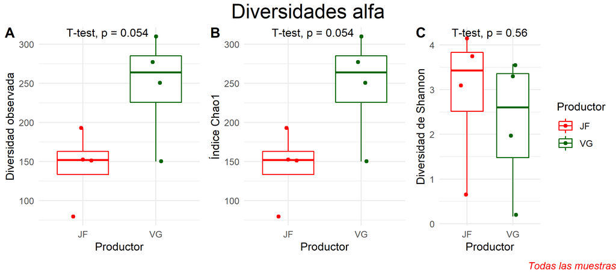

Alt text

Fig 4: Alpha diversity of the communities present in JF and VG vineyards after the removal of “Before grinding” samples, mesured as Observed diversity, Chao1 index and Shannon diversity

[figure not shown]

Alt text

- **Beta diversity of the microbiota associated in JF and VG ‘pajarete’ producers**

The Figure 5 shows a MDS plot with beta diversity results. UNIFRAC and Bray-Curtis metrics were conducted followed by its subsequent PERMANOVA (F1,6 = 2,16; P = 0,15 y F1,6 = 0,24; P = 0,089, respectively). As seen, observed difference were not statistically significant. Nevertheless, it is a trend showed by data in which, regardless the phase of the production chain looked at, samples from the same producer seems to be more similar to each other than samples from the same phase, but from the other vineyard. This is true with the exception of those samples corresponding to “Before grinding” phase.

On the graph, each phase of the production chain has its own shape. Also, Red points represent samples from JF, while Green, samples from VG.

Fig 5: Beta diversity for samples of two vineyards measured with UNIFRAC and Bray-Curtis methods:

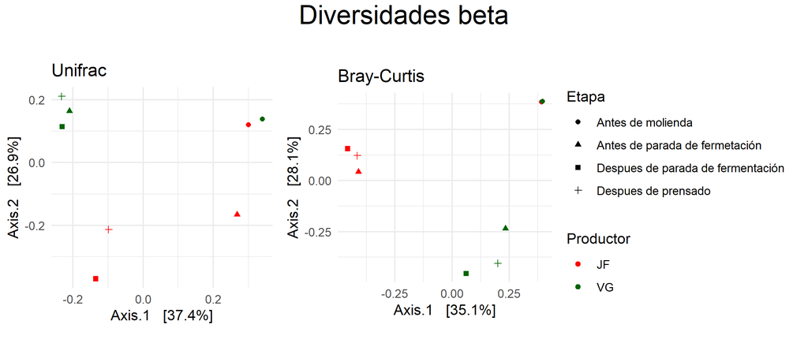

Alt text

- **Taxonomic features associated with each production processes:**

With the LefSe service, available in the web, the taxonomic features present in samples from the two ‘pajarete producers’ were identified. Figure 6 shows the results of this identification at the Family level in the taxonomic hierarchy. With red were signaled those samples collected from JF, while those from VG are showed in green

Fig 6: Specific taxonomic features identified in each of both production processes; JF and VG.

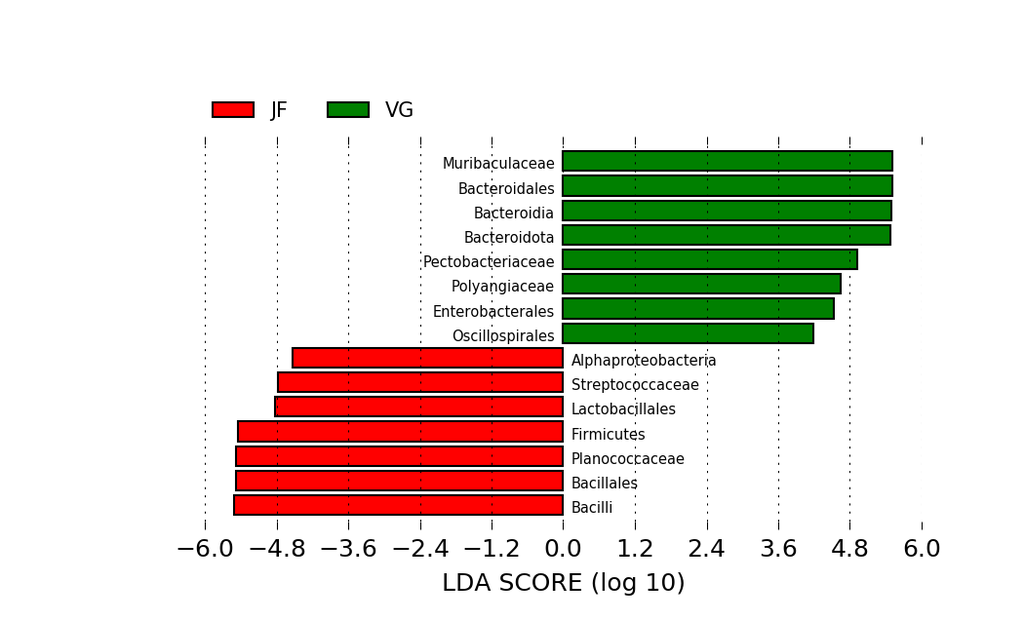

Alt text

Also with LefSe, the phylogenetic relationships of bacteira founded within samples of each producer of wine. This result was depicted in Figure 7. The figure shows in red those samples collected from JF and in green those from VG. Also, the legend shows to which taxonomic feature correspond each of the depicted areas within the phylogenetic tree.

Fig 7:Phylogenetic relationships between bacteria associated with each of both production processes; JF and VG.

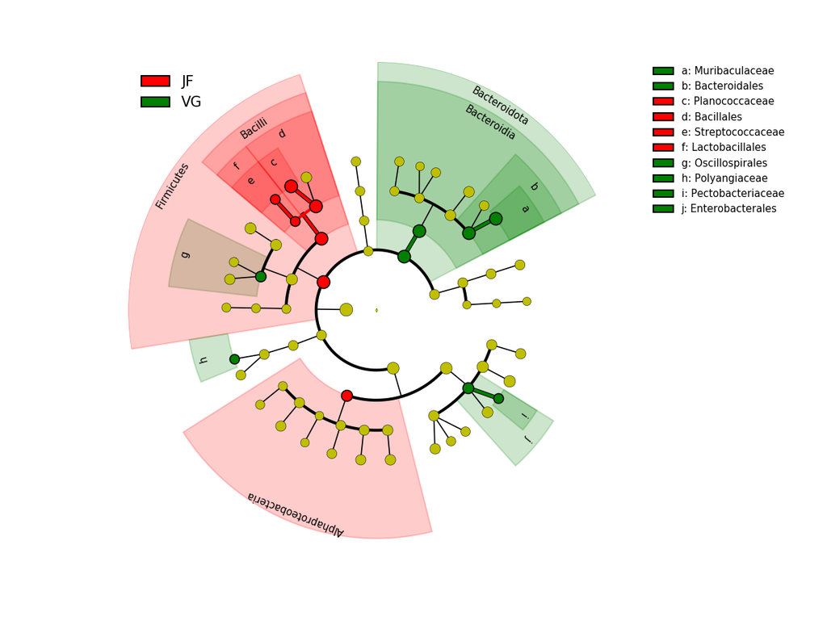

Alt text

- **Metabolic pathways inference:**

Fig 8: Metabolic pathways inferred from samples collected within JF and VG production chains. This pathways were inferred from the 16S rRNA sampled data.

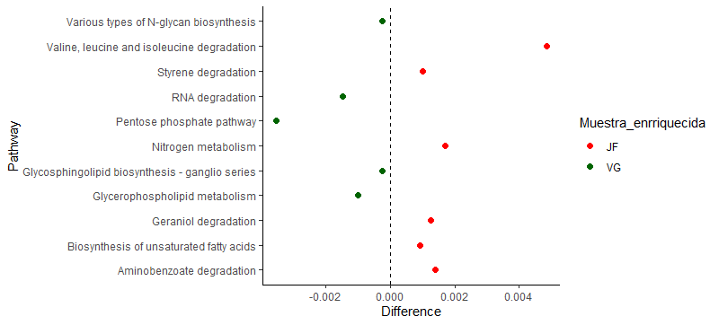

Alt text

**Discussion**

Because of the lack of previous literature dedicated to analyze the microbial community associated to the production of the ‘pajarete’, the results presented here, pointing the prevalence of *Firmicutes* and the later change in the composition of the biota, are new. Also, its causes can not be determined from the analysis conducted during this work. Nevertheless, a plausible explanation of this changes in the relative abundances is due to the different conditions the most is subject along the processing stages. Changes in temperature and pressure during the processing of the most can favor different phyla and/or families in each step, and could lead to the changing representation of those taxonomies within the samples.

Additionally, is worth to mention that the decision to analyze relative abundances of the collected samples just as deep as the family level of the hierarchy was due to the final number of reads for each sample. Some of them can not meet the usual standards for number of reads that can be seen in this type of experiments. As consequence, bacteria from some genus or species that are present in the community, can be underrepresented within the sample.

As said, the analysis of beta diversities shows a trend on which samples from each producer tend to be more similar within them, than they are with samples from the other producer even if it was collected at the same stage of the production process. However, this is not the case for samples corresponding to “Before grinding” stage, where they tend to be much more similar within them than with other samples, no matter the producer of which they come from. This suggest that before the production process used in each vineyard, all communities tend to be closely related in terms of their diversities, but along the processing chain of the most, and due to different conditions used by each vineyard, communities tend to differentiate between them and come to cluster by its producer. Given the above, and even in consideration that differences are not statistically significant, the trend previously depicted rise the worry to increase the number of replicates and then conduct the same analysis

By the end of september 2020, there are no papers about the microbiota associated with the production of ‘pajarete’ in any of the scientific literature research engines. Nevertheless, reading the available literature which discuss the microbiota of other wines, it is interesting the reported presence of *Lactobacillaes* microbes, also noticed in ‘pajarete’, which are repeatedly discussed as important malolactic fermenters (Lonvaud-Funel, 1999; Reguant & Bordons, 2003), and therefore, play an important role in determining wine’s quality (Ilabaca, Jara, & Romero, 2014). Although *Alphaproteobacterias* were identified within the studied communities, its presence is not something to worry about, because non of the three genera known to be producers of acetic acid (Bartowsky & Henschke, 2008) were present in the samples. Other relevant aspect of the bacterial composition in the samples, is the presence of taxonomic features that has never been described before in wine’s literature. It opens the door for the exploration of the consequence of its presences in the produced ‘pajarete’. This is the case for *Muribaculaceae* and *Pectobactericeae* in VG vineyard, and *Planococcaceae* in JF.

The enrichment in the metabolic pathways associated with valine, leucine and isoleucine degradation in samples collected from JF is consistent with previous reports. The supplementation of low-linoleic-acid mosts with those aminoacids enhance the production of volatile compounds, like alcohol and others associated with wine’s flavor and aroma (Liu, Yu, Li, Duan, & Yan, 2018). In Liu’s paper, it was also concluded that linoleic acid can regulate the expression of genes involved in the production of volatile molecules within wines that were supplemented with this acid. Additionally, other research suggests that some unsaturated fatty acids -also detected as statistically significant in this study- are determinants in the final flavor and aroma of the produced wine, and, also, can affect the fermentative performance of *Saccharomyces cerevisiae* (Liu, Duan, & Yan, 2019).

Some pathways of the nitrogen metabolism, also enriched in samples from JF vineyard, had been associated with an increase in the concentration of metabolites produced during the alcoholic and malolactic fermentations (Lytra, Miot-Sertier, Moine, Coulon, & Barbe, 2020), being the last consistent with the detection of high presence of *Lactobacillales* within JF samples. These metabolites had been characterized as relevant for determining amoratic properties of the wine (Lytra et al., 2020). Also, the presence of geraniol and genaric acid has been reported as relevant for the same organoleptic properties named above, in different kinds of red and white italian wines (De Lorenzis, Squadrito, Brancadoro, & Scienza, 2015). Finally, other relevant result herein exposed is the pathway for benzyl alcohol and other benzoate derivatives, which confer fruity and floral flavors to wines (Martin et al., 2016).

Finally, it is necessary to make explicit an assumption used in the statistical analysis done in this report. All statistical test were made with samples from different stages along the production process of the ‘pajarete’. Because of each stage has just one replicate, it was impossible to know the effect of each step of the process in the observed differences when doing diversity, community composition or metabolic pathways statistical analysis. The decision to group samples from different steps comes from the assumption that all of them can reflect, globally, the entire process of production used by each vineyard. Although useful in term of statistical analysis, this assumption implies that the temporal structure which underlies the samples was deliberately ignored. Therefore, factors that without doubt affect the bacterial community studied, like time and the temperature or pressure conditions in which the most is processed to produce wine, were laid by side and not considered when trying to explain the observed differences. With all issues above discussed, results here exposed must be carefully analyzed and considered as a first approximation to this unexplored field.

**Final thoughts**

Without doubt it is desirable to integrate metagenomic studies with metatranscriptomic and metabolomic approaches. Nevertheless, due to its high cost, the present work shows the indirect prediction of metabolic pathways from the 16S rRNA marker gene. In consequence, it is relevant to conduct empirical work to test some hypothesis that emerged after this bioinformatic workflow. Interesting hypothesis to further explore are: which role plays this bacteria never described in wine samples before? Does metabolic pathways herein inferred correlate or explain some properties of the end product? What is the effect of the yeast involved in this process?

Additionally, an increase in the number of samples in each step of the production chain will allow to gain more deep insights about the inner dynamics of the bacterial community. Its composition, here analyzed in terms of relative abundances, changes along the production process, probably due to pressure and temperature conditions which it cross trough. Also, analysis of the community diversity shows a trend of differentiation, on which samples tend to follow a divergence process which end in major similarity within each producer that the observed similarity within production step.

Finally, it is interesting to mention that ‘pajarete’, a wine with appellation of origin and an historical background, was almost neglected in terms of its biological determinants for the production process and the end product. This is an opportunity to further explore the microbial community associated with this wine and, then, use this knowledge to enhance the organoleptic properties of a beverage that can only be produced here in Chile, and therefore, counts with high comparative advantages in the world market.

**Reference**

Bartowsky, E. J., & Henschke, P. A. (2008). Acetic acid bacteria spoilage of bottled red wine-a review.

Callahan, B. J., McMurdie, P. J., Rosen, M. J., Han, A. W., Johnson, A. J. A., & Holmes, S. P. (2016). DADA2: High-resolution sample inference from illumina amplicon data. *Nature Methods*, *13*(7), 581–583. Nature Publishing Group.

Castro, A., Pszczólkowski, P., Mujica, F., Lacoste, P., Núñez, E., Cofré, C., Adunka, M. L., et al. (2016). El pajarete de huasco y elqui (chile): Historia de un vino escogido. *Idesia (Arica)*, *34*(ahead), 0–0. SciELO Comision Nacional de Investigacion Cientifica Y Tecnologica (CONICYT).

De Lorenzis, G., Squadrito, M., Brancadoro, L., & Scienza, A. (2015). Zibibbo nero characterization, a red-wine grape revertant of muscat of alexandria. *Molecular Biotechnology*, *57*(3), 265–274. Humana Press Inc.

Ilabaca, C., Jara, C., & Romero, J. (2014). The rapid identification of lactic acid bacteria present in chilean winemaking processes using culture-independent analysis. *Annals of Microbiology*, *64*(4), 1857–1859. Springer Verlag.

Iwai, S., Weinmaier, T., Schmidt, B. L., Albertson, D. G., Poloso, N. J., Dabbagh, K., & DeSantis, T. Z. (2016). Piphillin: Improved prediction of metagenomic content by direct inference from human microbiomes. (Z. He, Ed.)*PLOS ONE*, *11*(11), e0166104. Public Library of Science.

Kanehisa, M., & Goto, S. (2000, January). KEGG: Kyoto encyclopedia of genes and genomes. Oxford University Press. Retrieved from https://pubmed-ncbi-nlm-nih-gov.pucdechile.idm.oclc.org/10592173/

Knight, R., Vrbanac, A., Taylor, B. C., Aksenov, A., Callewaert, C., Debelius, J., Gonzalez, A., et al. (2018). Best practices for analysing microbiomes. *Nature Reviews Microbiology*.

Lacoste, P., Castro, A., Rendón, B., Pszczólkowski, P., Soto, N., Adunka, M. L., Jeffs, J., et al. (2016). Asoleado de cauquenes y concepción: Apogeo y decadencia de un vino chileno con denominación de origen. *Idesia*, *34*(1), 85–99. Universidad de Tarapaca.

Liu, P. T., Duan, C. Q., & Yan, G. L. (2019). Comparing the effects of different unsaturated fatty acids on fermentation performance of saccharomyces cerevisiae and aroma compounds during red wine fermentation. *Molecules*, *24*(3). MDPI AG.

Liu, P. T., Yu, K. J., Li, Y. T., Duan, C. Q., & Yan, G. L. (2018). The content of linoleic acid in grape must influences the aromatic effect of branched-chain amino acids addition on red wine. *Food Research International*, *114*, 214–222. Elsevier Ltd.

Lonvaud-Funel, A. (1999). Lactic acid bacteria in the quality improvement and depreciation of wine. In *Antonie van leeuwenhoek, international journal of general and molecular microbiology* (Vol. 76, pp. 317–331). Springer.

Lytra, G., Miot-Sertier, C., Moine, V., Coulon, J., & Barbe, J. C. (2020). Influence of must yeast-assimilable nitrogen content on fruity aroma variation during malolactic fermentation in red wine. *Food Research International*, *135*. Elsevier Ltd.

Martin, V., Giorello, F., Fariña, L., Minteguiaga, M., Salzman, V., Boido, E., Aguilar, P. S., et al. (2016). De novo synthesis of benzenoid compounds by the yeast hanseniaspora vineae increases the flavor diversity of wines. *Journal of Agricultural and Food Chemistry*, *64*(22), 4574–4583. American Chemical Society.

Ozen, M., & Dinleyici, E. C. (2015, January). The history of probiotics: The untold story. Wageningen Academic Publishers. Retrieved from https://www.wageningenacademic.com/doi/abs/10.3920/BM2014.0103

Parker, M., Capone, D. L., Francis, I. L., & Herderich, M. J. (2018). Aroma precursors in grapes and wine: Flavor release during wine production and consumption. *Journal of Agricultural and Food Chemistry*, *66*(10), 2281–2286. American Chemical Society.

Quast, C., Pruesse, E., Yilmaz, P., Gerken, J., Schweer, T., Yarza, P., Peplies, J., et al. (2013). The silva ribosomal rna gene database project: Improved data processing and web-based tools. *Nucleic Acids Research*, *41*(D1), D590–D596. Oxford Academic.

Reguant, C., & Bordons, A. (2003). Typification of oenococcus oeni strains by multiplex rapd-pcr and study of population dynamics during malolactic fermentation. *Journal of Applied Microbiology*, *95*(2), 344–353. John Wiley & Sons, Ltd.

Segata, N., Izard, J., Waldron, L., Gevers, D., Miropolsky, L., Garrett, W. S., & Huttenhower, C. (2011). Metagenomic biomarker discovery and explanation. *Genome Biology*, *12*(6). Genome Biol.

Sirén, K., Mak, S. S. T., Fischer, U., Hansen, L. H., & Gilbert, M. T. P. (2019). Multi-omics and potential applications in wine production. *Current Opinion in Biotechnology*, *56*, 172–178.

Varela, C., & Borneman, A. R. (2017). Yeasts found in vineyards and wineries. *Yeast*, *34*(3), 111–128. John Wiley; Sons Ltd.

Yilmaz, P., Parfrey, L. W., Yarza, P., Gerken, J., Pruesse, E., Quast, C., Schweer, T., et al. (2014). The silva and "all-species living tree project (ltp)" taxonomic frameworks. *Nucleic Acids Research*, *42*(D1), D643–D648. Oxford Academic.